# Interaction: Approach x Mislocated Functional Requirements

Julian Frattini

2025-08-30

This notebook contains the analysis of the potential interaction effect between *TLR approach* (`approach`) and *Mislocated Functional Requirement* (`lostfr`) on the outcome (here: `f2`). The analysis provides insight into the hypothesis that some approaches perform differently well whether or not the use case contains a mislocated functional requirement.

## Data Loading

First, load the data for the observational analysis. The data set is procured by the data-preparation.Rmd notebook. This notebook assembles and casts the data appropriately and stores the results in the `rq4tlr-data.csv` file.

```r
df <- read.csv('./../data/rq4tlr-data.csv')
```

Scale all numeric variables to make their coefficient distributions easier to sample from.

```r
df <- df %>%
  mutate(across(
    c("size", "outlinks", "maxinlinks", "maxsteplength", "sencomplexity"),
    \(x) scale(x, center = TRUE))) %>%
  mutate(
    Approach = factor(Approach, levels=c("FTLR", "LiSSA", "IR", "VSM", "LSI"), ordered = FALSE),
    Category = factor(Category, levels=c("Embedding", "LLM", "Traditional"), ordered = FALSE),
  )

str(df)
```

```
## 'data.frame':    945 obs. of  41 variables:
##  $ Dataset         : chr  "etour" "etour" "etour" "etour" ...
##  $ File            : chr  "UC1" "UC1" "UC1" "UC1" ...
##  $ duplicate       : logi  FALSE FALSE FALSE FALSE FALSE FALSE ...
##  $ nameproblem     : logi  FALSE FALSE FALSE FALSE FALSE FALSE ...
##  $ scope           : logi  FALSE FALSE FALSE FALSE FALSE FALSE ...
##  $ textorder       : logi  FALSE FALSE FALSE FALSE FALSE FALSE ...
##  $ iounquantified  : logi  FALSE FALSE FALSE FALSE FALSE FALSE ...
##  $ actoractor      : logi  FALSE FALSE FALSE FALSE FALSE FALSE ...
##  $ justification   : logi  FALSE FALSE FALSE FALSE FALSE FALSE ...
##  $ coordambiguity  : num  0 0 0 0 0 0 0 0 0 0 ...
##  $ uidesign        : num  0 0 0 0 0 0 0 0 0 0 ...
##  $ alternative     : num  0 0 0 0 0 0 0 0 0 0 ...
##  $ inconsistentloa : num  0 0 0 0 0 0 0 0 0 0 ...
##  $ clarification   : num  0 0 0 0 0 0 0 0 0 0 ...
```

[output cut: 37 more lines]

The output shows by what factors the numeric variables were centered and scaled.

## Analysis

The analysis of the data employs a regression model in a Bayesian framework. The utilized formula only assumes an intercept (i.e., a baseline), an offset per dataset, and the interaction effect between `approach` and the current variable of interest.

```r
f <- F2 ~ 0 + Intercept + Dataset + Approach*lostfr
get_prior(f, data=df, family=zero_one_inflated_beta)
```

```
##              prior class                     coef group resp dpar nlpar lb ub
##             (flat)     b
##             (flat)     b               ApproachIR
##             (flat)     b    ApproachIR:lostfrTRUE
##             (flat)     b            ApproachLiSSA
##             (flat)     b ApproachLiSSA:lostfrTRUE
##             (flat)     b              ApproachLSI
##             (flat)     b   ApproachLSI:lostfrTRUE
##             (flat)     b              ApproachVSM
##             (flat)     b   ApproachVSM:lostfrTRUE
##             (flat)     b            Datasetitrust
##             (flat)     b                Intercept
##             (flat)     b               lostfrTRUE
##         beta(1, 1)   coi                                                 0  1
##  gamma(0.01, 0.01)   phi                                                 0
##         beta(1, 1)   zoi                                                 0  1
##  tag       source
##           default
##      (vectorized)
##      (vectorized)
##      (vectorized)
##      (vectorized)
##      (vectorized)
##      (vectorized)
##      (vectorized)
##      (vectorized)
##      (vectorized)
##      (vectorized)
##      (vectorized)
##           default
##           default
##           default
```

Given this formula, select uninformative distributions for each of the coefficient distributions.

```r
p1 <- c(
  prior(normal(0, 1), class = b, coef = "Intercept"),
  prior(normal(0, 0.5), class = b),
  prior(gamma(4, 1), class = phi),
  prior(beta(7, 2), class = coi),
  prior(beta(5, 2), class = zoi)
)
```

To confirm the eligibility of the prior distributions, perform a prior predictive check.

```r
m.prior <-
  brm(data = df, family = zero_one_inflated_beta, f, prior = p1,
    iter = 4000, warmup = 1000, chains = 4, cores = 4,
    seed = 4, sample_prior="only",
    file = "../fits/int.f2.approach.lostfr.prior"
  )
```

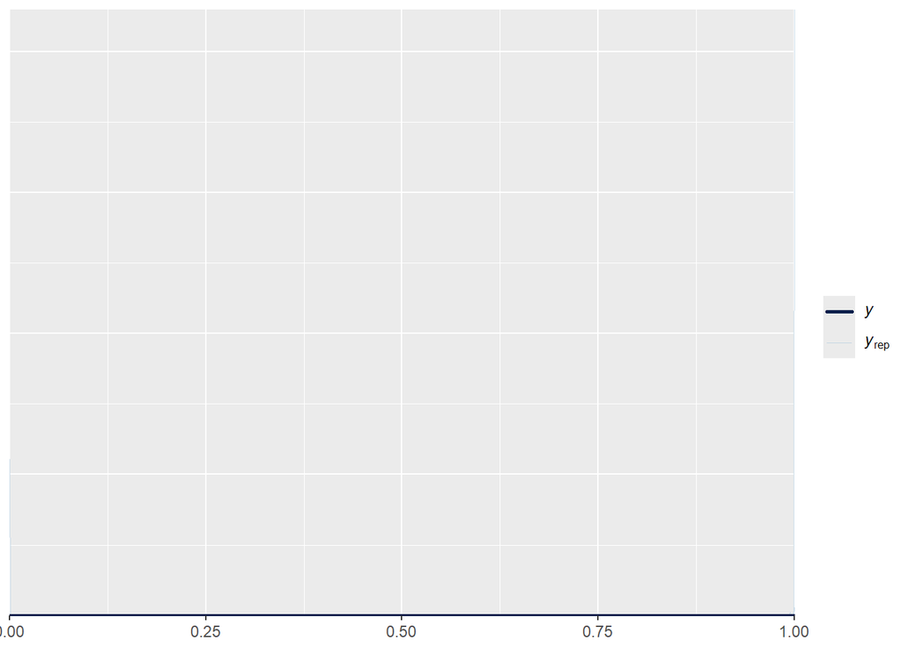

```r
brms::pp_check(m.prior, ndraws=100)
```

Due to the number of interaction effects and the relatively wide priors, the estimation ($y_{rep}$) clusters around the extremes of the spectrum. This is, however, expected and will be overwhelmed by the number of data points.

Given the eligibility of the priors, train the full model by updating the coefficient distributions in light of the observed data.

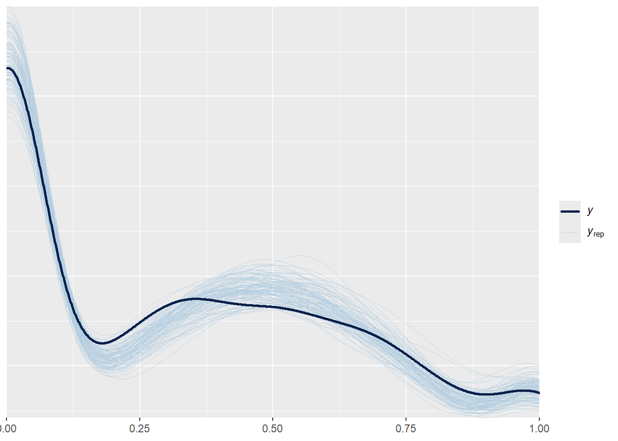

```r
m <-
  brm(data = df, family = zero_one_inflated_beta, f, prior = p1,
    iter = 4000, warmup = 1000, chains = 4, cores = 4, seed = 4,
    file = "../fits/int.f2.approach.lostfr"
  )

brms::pp_check(m, ndraws=100)
```

The posterior predictive check confirms that the model trained properly.

### Evaluation

To evaluate the trained model and draw conclusions about the hypothesized conditional effect, we first look at the updated path coefficients in the model summary. These coefficients are in relation to one selected baseline approach (here: `FTLR`) and represent the average slope difference.

```r
summary(m)
```

```
##  Family: zero_one_inflated_beta
##   Links: mu = logit
## Formula: F2 ~ 0 + Intercept + Dataset + Approach * lostfr
##    Data: df (Number of observations: 945)
##   Draws: 4 chains, each with iter = 4000; warmup = 1000; thin = 1;
##          total post-warmup draws = 12000
##
## Regression Coefficients:
##                          Estimate Est.Error l-95% CI u-95% CI Rhat Bulk_ESS
## Intercept                    0.29      0.08     0.14     0.45 1.00     7504
## Datasetitrust               -0.39      0.07    -0.52    -0.26 1.00    12846
## ApproachLiSSA                0.13      0.10    -0.05     0.33 1.00     9110
## ApproachIR                  -0.53      0.09    -0.72    -0.35 1.00     8744
## ApproachVSM                 -0.14      0.11    -0.36     0.08 1.00     9590
## ApproachLSI                  0.10      0.11    -0.11     0.31 1.00     9922
## lostfrTRUE                   0.16      0.22    -0.27     0.60 1.00    10728
## ApproachLiSSA:lostfrTRUE     0.40      0.34    -0.26     1.08 1.00    12237
## ApproachIR:lostfrTRUE        0.29      0.33    -0.36     0.95 1.00    13276
## ApproachVSM:lostfrTRUE      -0.42      0.36    -1.12     0.27 1.00    13595
## ApproachLSI:lostfrTRUE      -0.55      0.33    -1.21     0.12 1.00    13989
##                          Tail_ESS
## Intercept                    8674
## Datasetitrust                8520
## ApproachLiSSA                8902
## ApproachIR                   9206
## ApproachVSM                  9065
## ApproachLSI                  9546
## lostfrTRUE                   9277
## ApproachLiSSA:lostfrTRUE     8790
## ApproachIR:lostfrTRUE        9705
## ApproachVSM:lostfrTRUE       8329
## ApproachLSI:lostfrTRUE       9917
##
## Further Distributional Parameters:
##     Estimate Est.Error l-95% CI u-95% CI Rhat Bulk_ESS Tail_ESS
## phi     6.36      0.37     5.66     7.10 1.00    14146     8875
## zoi     0.45      0.02     0.42     0.48 1.00    16845     8785
## coi     0.14      0.02     0.11     0.17 1.00    15093     8719
##
## Draws were sampled using sampling(NUTS). For each parameter, Bulk_ESS
## and Tail_ESS are effective sample size measures, and Rhat is the potential
## scale reduction factor on split chains (at convergence, Rhat = 1).
```

More contextualized insights can be derived by plotting the conditional effect.

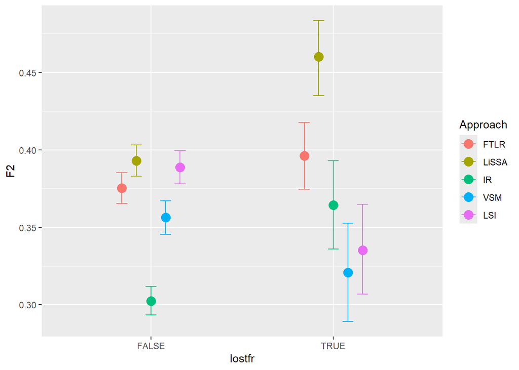

```r
conditional_effects(m, effects="lostfr:Approach",
                    prob = 0.5, method="posterior_epred")
```

These results invite the following interpretation.

- FTLR is the least sensitive as its working on the single fields and with majority voting from code files and not from the requirements side.
- LiSSA can use the information anyways as its able to derive semantics better

It is unclear why VSM and LSI do not seem to be able to derive helpful information from the additional functional requirements.